# A2.2 LDA y árboles de decisión

4. Genera un modelo usando la metodología de árboles de decisión. Deberás podar el árbol, habiendo seleccionado primero un valor óptimo de $𝛼$ mediante una metodología de LOOCV. Visualiza tanto el árbol resultante, como la partición en una gráfica de variable 1 vs variable 2, donde cada observación tenga algo que la distinga dependiendo de su clase.

```
Mejor α encontrado: 0.005263157894736842
```

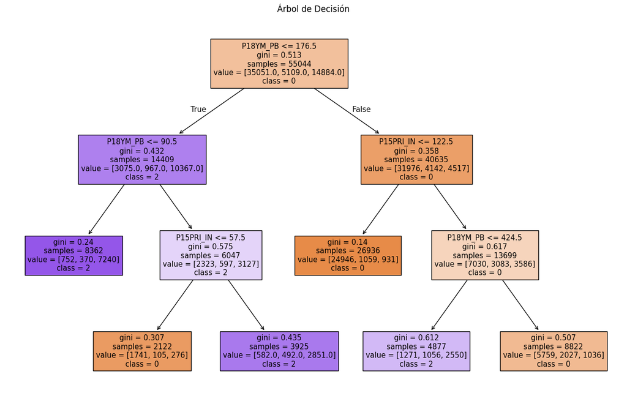

```python
arbol_base=DecisionTreeClassifier(random_state=42)
arbol_base.fit(x_train, y_train)
param_grid={'ccp_alpha': np.linspace(0, 0.1, 20)}
grid_search=GridSearchCV(DecisionTreeClassifier(random_state=42), param_grid, cv=5, scoring='accuracy')
grid_search.fit(x_train, y_train)
best_alpha=grid_search.best_params_['ccp_alpha']
print(f"Mejor α encontrado: {best_alpha}")
arbol_podado=DecisionTreeClassifier(random_state=42, ccp_alpha=best_alpha)
arbol_podado.fit(x_train, y_train)
plt.figure(figsize=(16, 10))
plot_tree(arbol_podado, filled=True, feature_names=['P18YM_PB', 'P15PRI_IN'], class_names=np.unique(y_train).astype(str))
plt.title("Árbol de Decisión")
plt.show()
```

5. Calcula, para ambos modelos, todas las métricas revisadas en clase en los datos de prueba. Indica qué opinas sobre los resultados, especificando si crees que uno de los dos modelos es mejor para esta tarea específica.

```
	 Linear Discriminant Analysis
Accuracy: 0.8398
Precision: 0.8151
Recall: 0.8398
F1-Score: 0.8189
```

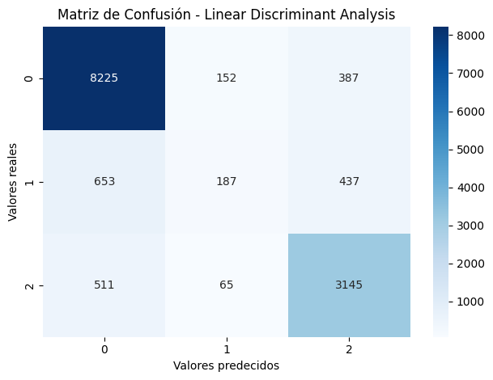

```
Reporte de clasificación:
              precision    recall  f1-score   support

           0       0.88      0.94      0.91      8764
           1       0.46      0.15      0.22      1277
           2       0.79      0.85      0.82      3721

    accuracy                           0.84     13762
   macro avg       0.71      0.64      0.65     13762
weighted avg       0.82      0.84      0.82     13762

	 Árbol de Decisión
Accuracy: 0.8187
Precision: 0.7447
Recall: 0.8187
F1-Score: 0.7797
```

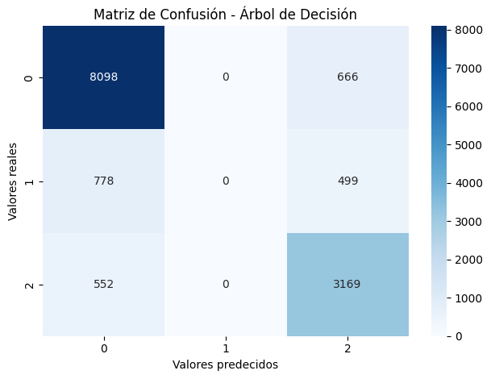

```
Reporte de clasificación:
              precision    recall  f1-score   support

           0       0.86      0.92      0.89      8764
           1       0.00      0.00      0.00      1277
           2       0.73      0.85      0.79      3721

    accuracy                           0.82     13762
   macro avg       0.53      0.59      0.56     13762
weighted avg       0.74      0.82      0.78     13762
```

```python
y_pred_arbol=arbol_podado.predict(x_test)
def evaluar_modelo(y_test, y_pred, nombre_modelo):
    print("\t", nombre_modelo)
    print(f"Accuracy: {accuracy_score(y_test, y_pred):.4f}")
    print(f"Precision: {precision_score(y_test, y_pred, average='weighted'):.4f}")
    print(f"Recall: {recall_score(y_test, y_pred, average='weighted'):.4f}")
    print(f"F1-Score: {f1_score(y_test, y_pred, average='weighted'):.4f}")
    cm=confusion_matrix(y_test, y_pred)
    sns.heatmap(cm, annot=True, fmt='d', cmap='Blues', xticklabels=np.unique(y_test), yticklabels=np.unique(y_test))
    plt.ylabel('Valores reales')
    plt.xlabel('Valores predecidos')
    plt.title(f'Matriz de Confusión - {nombre_modelo}')
    plt.tight_layout()
    plt.show()
    print("\nReporte de clasificación:")
    print(classification_report(y_test, y_pred))
evaluar_modelo(y_test, y_pred_lda, "Linear Discriminant Analysis")
evaluar_modelo(y_test, y_pred_arbol, "Árbol de Decisión")
```

**Firma de Honor:** Doy mi palabra que he realizado esta actividad con integridad académica